# lab4

```python
%matplotlib inline
import numpy as np
import matplotlib
import matplotlib.pyplot as plt
import scipy
from scipy import stats
import h5py
#this sets the size of the plot to something useful
plt.rcParams["figure.figsize"] = (10,5)
```

```python
#conda install -c conda-forge xarray dask netCDF4 bottleneck
import xarray as xr
```

```python
hf = h5py.File('gammaray_lab4.h5', 'r')
hf.keys()
data = np.array(hf.get('data'))
```

```python
data[:,0]
```

```
array([9.40680016e+08, 3.15000000e+02, 4.50000000e+01, 1.00000000e+01])
```

# Problem 1

To get some general understandings of the data, and prevent my computer to be melt down by the data set. I set the number of data to plot to be 500,000(call it num). We can change it later.

```python
time = data[0]
sol_pha = data[1]
ear_long = data[2]
par_count = data[3]
num = 500000
```

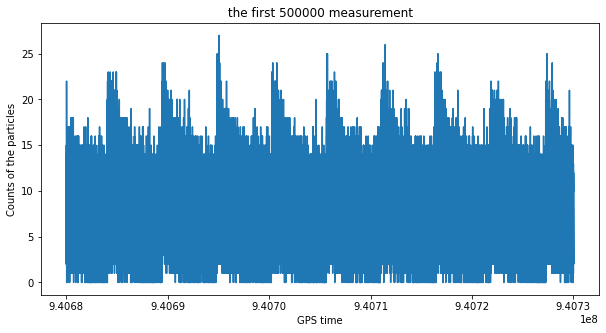

```python
plt.title(f" the first {num} measurement ")
plt.xlabel('GPS time')
plt.ylabel('Counts of the particles')
plt.plot(time[0:num], par_count[0:num])
```

There is some pattern showed up. Test the other two variables to see if they have something similar. Besides, the way satellite works (or we can say GPS works) is by creating extremely accurate time and find out the difference between time of the electro-magnetic waves from different satellite to arrive at a location on Earth. As a result, I set the time in of GPS to be my independent variable and the others to be dependent variables to see what's going on here. \ \ We have already test the particle counts, then we test the solar phase, followed by Earth longitude and put them together to see if there is any pattern.

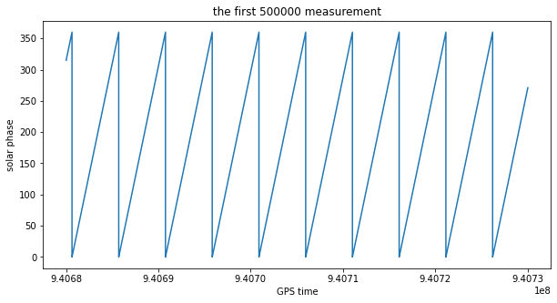

```python
plt.title(f" the first {num} measurement ")
plt.xlabel('GPS time')
plt.ylabel('solar phase')
plt.plot(time[0:num], sol_pha[0:num])
```

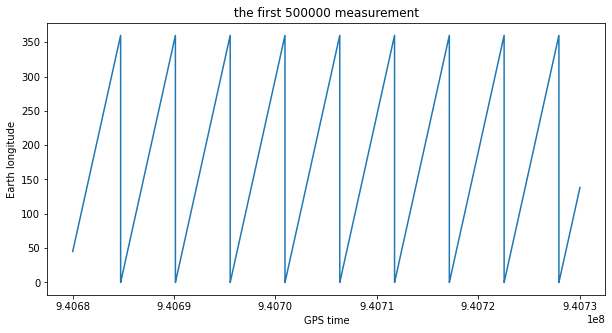

```python
plt.title(f" the first {num} measurement ")
plt.xlabel('GPS time')
plt.ylabel('Earth longitude')
plt.plot(time[0:num], ear_long[0:num])
```

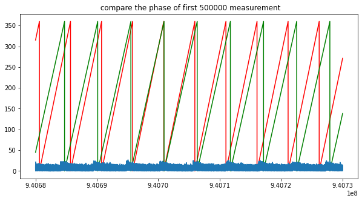

```python
plt.title(f" compare the phase of first {num} measurement")
plt.plot(time[0:num], sol_pha[0:num], 'r')
plt.plot(time[0:num], ear_long[0:num],'g')
plt.plot(time[0:num], par_count[0:num])
```

Below，I create a model for the background that includes time dependence, and explicitly compare the model to the data.

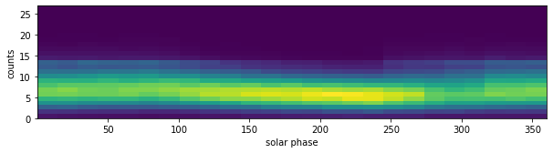

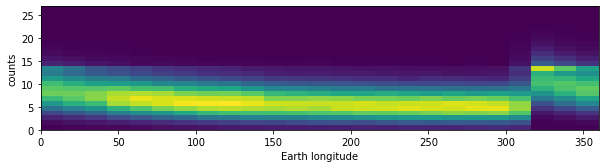

```python
plt.subplot(2, 1, 1)
plt.xlabel('solar phase')
plt.ylabel('counts')
sol_par = plt.hist2d(sol_pha[:num], par_count[:num], bins=(25, 25),density = True)
plt.show()
plt.subplot(2, 1, 2)
plt.xlabel('Earth longitude')
plt.ylabel('counts')
ear_par = plt.hist2d(ear_long[:num], par_count[:num], bins=(25, 25), density = True)
plt.show()
```

Below, I estimate the background and compare explicitly

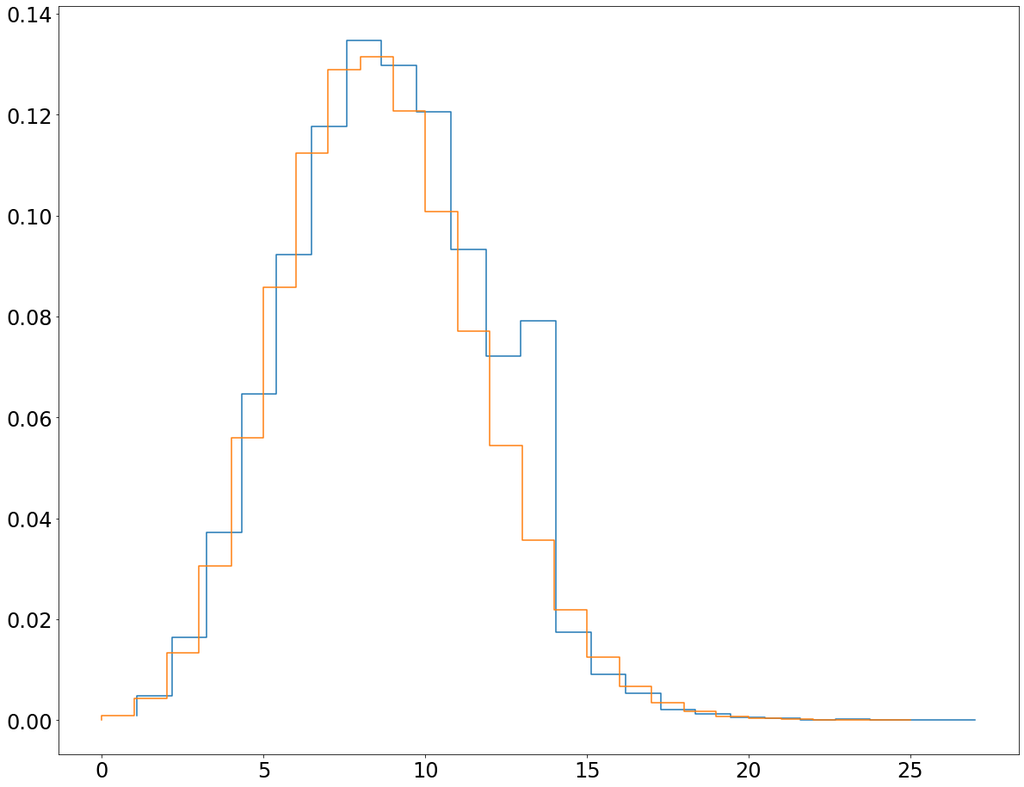

```python
factor = 1/sum(ear_par[0][0])
x = ear_par[2][1:]
plt.figure(figsize=(20, 16))
plt.step(x, ear_par[0][0,:]*factor)
plt.tick_params(labelsize = 24)


# Model using Poisson distribution and means from our data
means = [np.mean(data[3][data[2]==i]) for i in np.arange(360)]
mu = means[0]
x=np.arange(0,26)
plt.step(x, stats.poisson.pmf(x,mu))
plt.show()
```

```python
min_phase = np.argmin(means)
min_count = means[min_phase]
print(f"Lowest count:{min_count:.1f} ,orbit phase {min_phase:.1f}")
max_phase = np.argmax(means)
max_count = means[max_phase]
print(f"Highest count: {max_count:.1f} ,orbit phase {max_phase:.1f}")
```

```
Lowest count:5.6 ,orbit phase 314.0
Highest count: 11.3 ,orbit phase 318.0
```

```python
five_sig = stats.norm.sf(5)
min_sig = stats.poisson.isf(five_sig, min_count)
max_sig = stats.poisson.isf(five_sig, max_count)
time_min_sig = min_phase / 360 * 60 * 90
time_max_sig = max_phase / 360 * 60 * 90
print(f"for a count of {min_sig:.0f} in 100 milliseconds, the 5-sigma threshold is fulfilled, and the time is {time_min_sig:.0f} seconds after the experiment started")
print(f"for a count of {max_sig:.0f} in 100 milliseconds, the 5-sigma threshold is fulfilled, and the time is {time_max_sig:.0f} seconds after the experiment started")
```

```
for a count of 21 in 100 milliseconds, the 5-sigma threshold is fulfilled, and the time is 4710 seconds after the experiment started
for a count of 32 in 100 milliseconds, the 5-sigma threshold is fulfilled, and the time is 4770 seconds after the experiment started
```

After googling the information, I think my analysis is realated to the Van Allen radiation belt.

# Problem 2

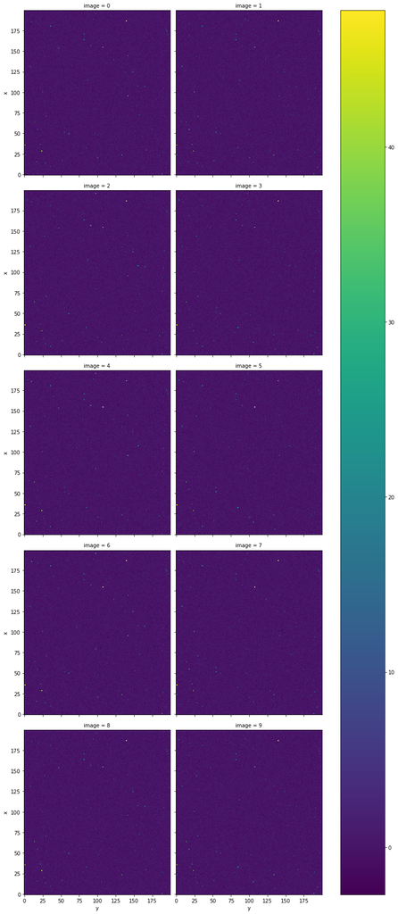

```python
hf5 = h5py.File('images.h5', 'r')
stack = xr.DataArray(hf5.get('imagestack')[:,:,:], coords=[np.arange(200), np.arange(200),np.arange(10)],
                     dims=['x', 'y', 'image']).transpose('image','x','y')
stack.plot(center=False, col='image', col_wrap=2, size=5)
images_data = np.array(hf5.get('imagestack'))
plt.show()
```

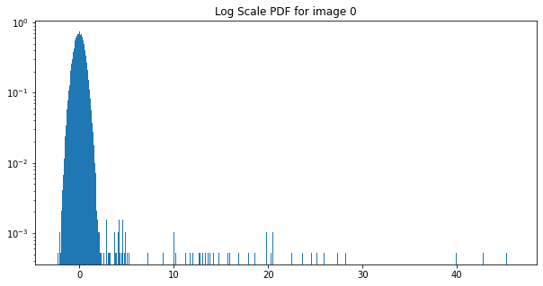

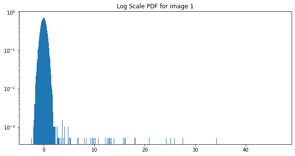

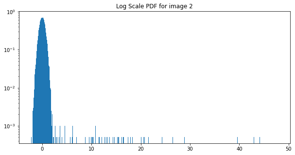

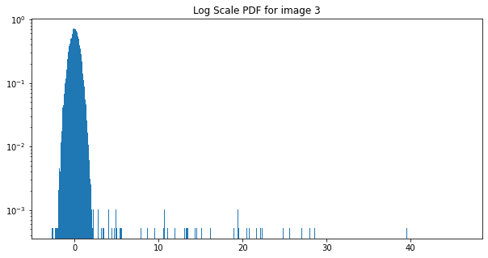

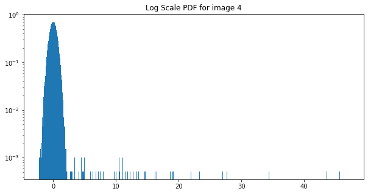

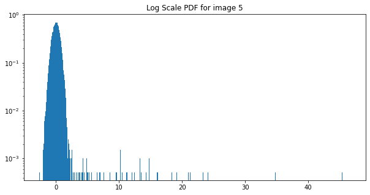

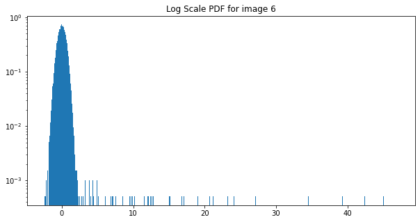

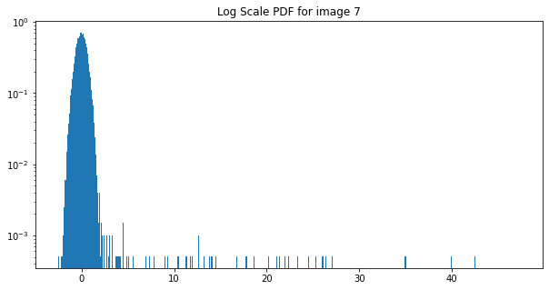

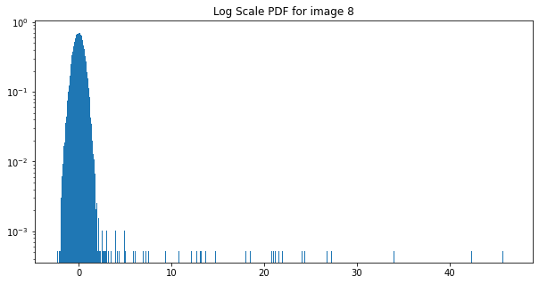

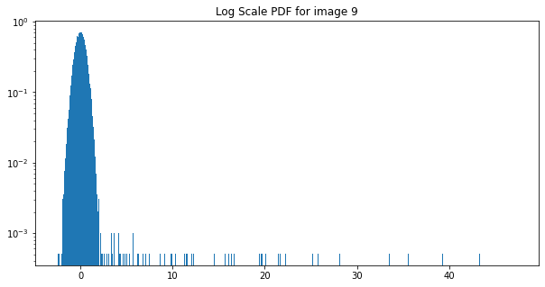

```python
for i in np.arange(10):
    # remember index starts at 0
    stack[i].plot.hist(bins=1000, density=True, size=5)
    plt.title(f"Log Scale PDF for image {i}")
    plt.yscale("log")
    plt.show()
```

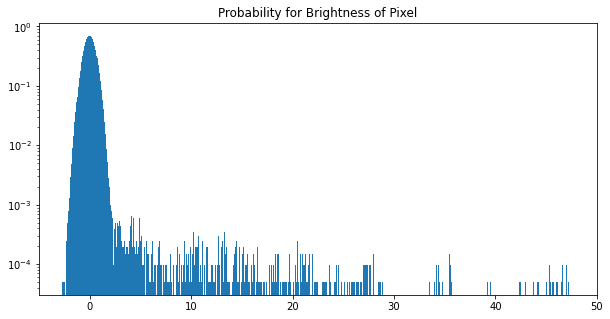

```python
# we overlay all of them and see
stack.plot.hist(bins=1000, density=True, size=5)
plt.title("Probability for Brightness of Pixel")
plt.xlim([-5,50])
plt.yscale('log')
plt.show()
```

From the plot above, I don't think the data is contaminated and it is not related to time. The background is Gaussian distribution, but we still don't know the parameters of this distribtuion. Below, i will find the parameters of the background distribution.

```python
max_hf = []
mean_hf =[]
min_hf = []
for i in np.arange(10):
    max_hf.append(np.max(stack[i].values))
    mean_hf.append(np.mean(stack[i].values))
    min_hf.append(np.min(stack[i].values))
    print(f"max value of {i}: {np.max(stack[i].values)}, min {np.min(stack[i].values)}, mean {np.mean(stack[i].values)}")
```

```
max value of 0: 46.01175269422071, min -2.283915564822921, mean 0.030218566576240936
max value of 1: 46.592267064916705, min -2.431318269785951, mean 0.030805866173257253
max value of 2: 47.79010819628649, min -2.2423795336690366, mean 0.03804687710376909
max value of 3: 46.081120603006916, min -2.709336827866645, mean 0.03359187121452332
max value of 4: 47.0003865702652, min -2.25293270073526, mean 0.034415489746337076
max value of 5: 46.621316029297525, min -2.6496072842241567, mean 0.038142677896534125
max value of 6: 46.99131843066182, min -2.4226087000140812, mean 0.028322878663590813
max value of 7: 47.26324939630629, min -2.491442987659155, mean 0.03184659318355503
max value of 8: 46.4883943499121, min -2.311568015810453, mean 0.03324503541571217
max value of 9: 47.21296880302628, min -2.4444978266413235, mean 0.03580179806386976
```

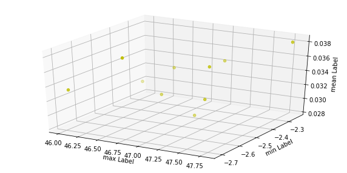

```python
from mpl_toolkits.mplot3d import Axes3D
import matplotlib.pyplot as plt

fig = plt.figure()
ax = fig.add_subplot(111, projection='3d')

ax.scatter(max_hf, min_hf, mean_hf, c='y', marker='o')

ax.set_xlabel('max Label')
ax.set_ylabel('min Label')
ax.set_zlabel('mean Label')

plt.show()
```

After comparing all the data above, I notice few outliers, No.5, No.2 and No.7. These three points looked different to the others. Then, after comparing with the log plot, I think there is a bright transient happened in image No.2.

```python
stack_No2 = stack.where(stack < 3)
mean = stack_No2.mean().values
std = stack_No2.std().values

print(f"background Gaussian distribution has parameters of  {mean:.3f} and {std:.3f}")
```

```
background Gaussian distribution has parameters of  0.001 and 0.563
```

```python
img_5sig = stats.norm.isf(stats.norm.sf(5), loc=mean, scale=std)
print(f"A detection of at least {img_5sig:.2f} would be a 5 sigma event")
for i in np.arange(10):
    n = stack[i].where(stack[i] > img_5sig).count().values
    print(f" 5 sigma events for image {i}: is {n}")
```

```
A detection of at least 2.82 would be a 5 sigma event
 5 sigma events for image 0: is 101
 5 sigma events for image 1: is 101
 5 sigma events for image 2: is 101
 5 sigma events for image 3: is 99
 5 sigma events for image 4: is 99
 5 sigma events for image 5: is 98
 5 sigma events for image 6: is 101
 5 sigma events for image 7: is 96
 5 sigma events for image 8: is 98
 5 sigma events for image 9: is 101
```

```python
img_10sig = stats.norm.isf(stats.norm.sf(10), loc=mean, scale=std)
print(f"A detection of at least {img_10sig:.2f} would be a 20 sigma event")
for i in np.arange(10):
    n = stack[i].where(stack[i] > img_10sig).count().values
    print(f" 10 sigma events for image {i}: is {n}")
```

[output not shown]

```python
img_30sig = stats.norm.isf(stats.norm.sf(30), loc=mean, scale=std)
print(f"A detection of at least {img_30sig:.2f} would be a 30 sigma event")
for i in np.arange(10):
    n = stack[i].where(stack[i] > img_30sig).count().values
    print(f" 30 sigma events for image {i}: is {n}")
```

```
A detection of at least 16.90 would be a 30 sigma event
 30 sigma events for image 0: is 27
 30 sigma events for image 1: is 27
 30 sigma events for image 2: is 26
 30 sigma events for image 3: is 26
 30 sigma events for image 4: is 26
 30 sigma events for image 5: is 26
 30 sigma events for image 6: is 27
 30 sigma events for image 7: is 26
 30 sigma events for image 8: is 27
 30 sigma events for image 9: is 26
```

```python
img_40sig = stats.norm.isf(stats.norm.sf(40), loc=mean, scale=std)
print(f"A detection of at least {img_40sig:.2f} would be a 40 sigma event")
for i in np.arange(10):
    n = stack[i].where(stack[i] > img_40sig).count().values
    print(f" 40 sigma events for image {i}: is {n}")
```

```
A detection of at least inf would be a 40 sigma event
 40 sigma events for image 0: is 0
 40 sigma events for image 1: is 0
 40 sigma events for image 2: is 0
 40 sigma events for image 3: is 0
 40 sigma events for image 4: is 0
 40 sigma events for image 5: is 0
 40 sigma events for image 6: is 0
 40 sigma events for image 7: is 0
 40 sigma events for image 8: is 0
 40 sigma events for image 9: is 0
```

Plug in differnet values of sigma does not work. I might need to write a loop or something like that. I think there is no transient in it.

```python
img_40sig = stats.norm.isf(stats.norm.sf(40), loc=mean, scale=std)
print(f"A detection of at least {img_40sig:.2f} would be a 40 sigma event")
for i in np.arange(10):
    n = stack[i].where(stack[i] > img_40sig).count().values
    print(f" 40 sigma events for image {i}: is {n}")
```

```
A detection of at least inf would be a 40 sigma event
 40 sigma events for image 0: is 0
 40 sigma events for image 1: is 0
 40 sigma events for image 2: is 0
 40 sigma events for image 3: is 0
 40 sigma events for image 4: is 0
 40 sigma events for image 5: is 0
 40 sigma events for image 6: is 0
 40 sigma events for image 7: is 0
 40 sigma events for image 8: is 0
 40 sigma events for image 9: is 0
```

```python
# test different sigma and try to find the transient
for i in [30,31,32,33,34,35,36,37,38,39,40]:
    img_sig = stats.norm.isf(stats.norm.sf(i), loc=mean, scale=std)
    for j in np.arange(10):
        n = stack[j].where(stack[j] > img_sig).count().values
        if n < 10:
            print(f"when we have a sigma value of {i}")
            print(f"the image with index {j} image have a transient")
        break
```

```
when we have a sigma value of 38
the image with index 0 image have a transient
when we have a sigma value of 39
the image with index 0 image have a transient
when we have a sigma value of 40
the image with index 0 image have a transient
```

In short, the reason is we have different PDF. I focus on the average differences between images and the person who do the faint task will have a PDF summed over multiple trials.